# R语言统计与建模

小天使格礼

# 目录

本教程涵盖R语言统计与建模的12个核心主题，每个章节均包含数学原理阐释与代码实现。

## 章节概览

| 章节 | 主题 | 主要内容 |
| --- | --- | --- |
| 第一章 | 线性回归模型 | 多元线性回归、OLS估计、残差分析、变量选择、正则化 |
| 第二章 | 广义线性模型 | 逻辑回归、泊松回归、负二项回归、零膨胀模型 |
| 第三章 | 混合效应模型 | 线性混合模型、随机效应、GLMM、重复测量分析 |
| 第四章 | 时间序列分析 | 时间序列分解、ARIMA、SARIMA、GARCH模型 |
| 第五章 | 生存分析 | Kaplan-Meier估计、Cox回归、竞争风险模型 |
| 第六章 | 多元统计分析 | PCA、因子分析、聚类分析、判别分析 |
| 第七章 | 面板数据模型 | 固定效应、随机效应、Hausman检验、动态面板 |
| 第八章 | 结构方程模型 | 路径分析、验证性因子分析、潜变量增长模型 |
| 第九章 | 非参数与半参数回归 | 核密度估计、LOESS、样条回归、GAM |
| 第十章 | 计量经济学方法 | 工具变量、断点回归、双重差分、倾向得分匹配 |
| 第十一章 | 模型选择与诊断 | 信息准则、交叉验证、残差诊断、影响点检测 |
| 第十二章 | 贝叶斯统计建模 | 贝叶斯推断、MCMC、贝叶斯回归、模型比较 |

## 详细目录

### 第二章：广义线性模型

- 2.1 指数族分布与链接函数
- 2.2 二元逻辑回归
- 2.3 多项逻辑回归
- 2.4 序数逻辑回归
- 2.5 泊松回归
- 2.6 负二项回归
- 2.7 准似然与过度离散
- 2.8 零膨胀模型

### 第三章：混合效应模型

- 3.1 线性混合模型基本结构
- 3.2 随机截距与随机斜率
- 3.3 嵌套与交叉设计
- 3.4 广义线性混合模型
- 3.5 模型拟合与推断
- 3.6 预测随机效应（BLUP）
- 3.7 重复测量数据分析

### 第四章：时间序列分析

- 4.1 时间序列分解
- 4.2 平稳性概念与检验
- 4.3 自相关与偏自相关
- 4.4 ARIMA模型
- 4.5 季节性ARIMA
- 4.6 GARCH模型

### 第五章：生存分析

- 5.1 生存函数与风险函数
- 5.2 Kaplan-Meier估计
- 5.3 对数秩检验
- 5.4 Cox比例风险模型
- 5.5 参数生存模型
- 5.6 竞争风险模型

### 第六章：多元统计分析

- 6.1 主成分分析
- 6.2 因子分析
- 6.3 聚类分析
- 6.4 判别分析
- 6.5 多维尺度分析

### 第七章：面板数据模型

- 7.1 面板数据结构
- 7.2 固定效应模型
- 7.3 随机效应模型
- 7.4 Hausman检验
- 7.5 动态面板模型
- 7.6 面板二值选择模型

### 第八章：结构方程模型

- 8.1 路径分析
- 8.2 验证性因子分析
- 8.3 结构模型与拟合评价
- 8.4 潜变量增长模型

### 第九章：非参数与半参数回归

- 9.1 核密度估计
- 9.2 局部加权回归
- 9.3 样条回归
- 9.4 广义加性模型

### 第十章：计量经济学专门方法

- 10.1 工具变量法
- 10.2 断点回归设计
- 10.3 双重差分法
- 10.4 倾向得分匹配
- 10.5 分位数回归

### 第十一章：模型选择与诊断

- 11.1 信息准则
- 11.2 交叉验证
- 11.3 残差诊断
- 11.4 影响点诊断

### 第十二章：贝叶斯统计建模

- 12.1 贝叶斯推断原理
- 12.2 MCMC方法
- 12.3 贝叶斯线性回归
- 12.4 贝叶斯模型比较

在Rstudio中安装本节课所有需要的包，运行以下指令：

```r
install.packages(c(
  "ggplot2", "dplyr", "tidyr", "broom", "gridExtra",
  "car", "MASS", "lmtest", "sandwich", "leaps", "glmnet", "splines",
  "pscl", "brant",
  "lme4", "nlme", "lmerTest",
  "forecast", "tseries", "vars", "rugarch", "fGarch",
  "survival", "survminer", "cmprsk",
  "FactoMineR", "factoextra", "cluster", "vegan", "mclust", "psych",
  "plm", "bife", "pglm",
  "lavaan", "semPlot",
  "mgcv",
  "AER", "MatchIt", "quantreg", "rdrobust",
  "rstanarm", "brms", "coda", "bayesplot", "loo",
  "boot", "caret", "AICcmodavg"
))
```

# 第一章：线性回归模型

线性回归是统计分析中最基础、应用最广泛的建模方法之一。本章将从模型原理出发，系统讲解多元线性回归的建模过程、参数估计、假设检验、诊断方法及扩展技术。

## 1.1 多元线性回归模型形式与假设

### 意义与使用场景

**核心意义**：多元线性回归用于研究一个连续型因变量与多个自变量之间的线性关系，是量化多因素影响、进行预测推断的基础工具。

**举例**：研究年龄、BMI、住院天数对医疗费用的影响

**为什么这种数据适合用线性回归？**

首先，因变量”医疗费用”是连续型数值变量（单位：元），取值范围从几百到几十万不等，符合线性回归对因变量的要求。其次，三个自变量——年龄（连续变量）、BMI（连续变量）、住院天数（连续变量）——都是可量化的数值型指标，且理论上与医疗费用存在近似线性的关系：年龄越大，慢性病越多，费用越高；BMI偏离正常范围越多，并发症风险越大；住院天数越长，累计费用越高。这种”连续因变量+多个连续自变量+近似线性关系”的数据结构，正是多元线性回归的典型适用场景。

**研究目的是什么？**

本研究有三个层次的目的：1. 量化影响程度：回答”年龄每增加1岁，医疗费用平均增加多少元？“这类具体问题，为卫生经济学分析提供依据；2. 识别关键因素：在控制其他变量后，判断哪个因素对费用的影响最大，为医疗资源分配和干预策略提供指导；3. 预测应用：建立预测模型，根据患者特征预估医疗费用，辅助医院预算管理和医保控费。

**可能得到什么样的结果？**

假设回归结果为：费用 = -5000 + 200×年龄 + 150×BMI + 800×住院天数

**需要注意什么？**

线性回归假设变量间关系是线性的，但实际中可能存在非线性关系（如BMI与费用可能是U型曲线，过低或过高都增加风险）。此外，医疗费用通常右偏分布，可能需要对数变换。这些都需要在建模前进行探索性分析。

### 数学基础

**多元线性回归模型**：

描述因变量$Y$与多个自变量$X_1, X_2, \ldots, X_p$之间线性关系的统计模型。

**模型形式**：
$$Y_i =
\beta_0 + \beta_1 X_{i1} + \beta_2 X_{i2} + \cdots + \beta_p X_{ip} +
\varepsilon_i$$

**矩阵形式**：
$$\mathbf{Y} =
\mathbf{X}\boldsymbol{\beta} + \boldsymbol{\varepsilon}$$

**参数说明**： - $Y_i$：第$i$个观测的因变量值 - $X_{ij}$：第$i$个观测的第$j$个自变量值 - $\beta_0$：截距项 - $\beta_j$：第$j$个自变量的回归系数 - $\varepsilon_i$：随机误差项 - $\mathbf{Y}$：$n \times 1$的因变量向量 - $\mathbf{X}$：$n \times (p+1)$的设计矩阵 - $\boldsymbol{\beta}$：$(p+1) \times 1$的参数向量

**经典假设（高斯-马尔可夫假设）**：

| 假设 | 数学表达 | 含义 |
| --- | --- | --- |
| 线性性 | $E(\varepsilon_i) = 0$ | 误差期望为零 |
| 同方差性 | $Var(\varepsilon_i) = \sigma^2$ | 误差方差恒定 |
| 独立性 | $Cov(\varepsilon_i, \varepsilon_j) = 0$ | 误差相互独立 |
| 正态性 | $\varepsilon_i \sim N(0, \sigma^2)$ | 误差服从正态分布（推断需要） |
| 无多重共线性 | $rank(\mathbf{X}) = p+1$ | 自变量间无线性关系 |

**高斯-马尔可夫定理**：

在假设1-4满足时，OLS估计量是**最佳线性无偏估计量（BLUE）**： - **无偏性**：$E(\hat{\boldsymbol{\beta}}) = \boldsymbol{\beta}$ - **有效性**：在所有线性无偏估计量中方差最小

### 代码实现

```r
# ============================================================
# 模拟生成医疗费用数据集
# 场景：研究患者年龄、BMI、住院天数对医疗费用的影响
# ============================================================

# 设置样本量
n <- 200

# 生成自变量
age <- round(rnorm(n, mean = 55, sd = 12))        # 年龄（岁），均值55，标准差12
bmi <- round(rnorm(n, mean = 25, sd = 4), 1)      # BMI指数，均值25，保留1位小数
los <- round(rnorm(n, mean = 7, sd = 3))          # 住院天数，均值7天
los <- pmax(los, 1)                               # 约束：住院天数至少1天

# 生成因变量：医疗费用（元）
# 真实模型：费用 = 1000 + 50*年龄 + 200*BMI + 500*住院天数 + 误差
# 解释：基础费用1000元，年龄每增1岁费用增50元，BMI每增1费用增200元，住院每天增500元
medical_cost <- 1000 + 50 * age + 200 * bmi + 500 * los + rnorm(n, 0, 1500)
medical_cost <- pmax(round(medical_cost, 0), 0)   # 费用取整且非负

# 创建数据框
medical_data <- data.frame(
  patient_id = 1:n,
  age = age,
  bmi = bmi,
  los = los,
  medical_cost = medical_cost
)

# 查看数据结构
str(medical_data)
```

```
## 'data.frame':    200 obs. of  5 variables:
##  $ patient_id  : int  1 2 3 4 5 6 7 8 9 10 ...
##  $ age         : num  48 52 74 56 57 76 61 40 47 50 ...
##  $ bmi         : num  33.8 30.2 23.9 27.2 23.3 23.1 21.8 22.6 31.6 24.8 ...
##  $ los         : num  7 3 5 7 9 2 6 9 5 8 ...
##  $ medical_cost: num  15271 11099 11930 10466 14196 ...
```

```r
# 查看前几行数据
head(medical_data)
```

```
##   patient_id age  bmi los medical_cost
## 1          1  48 33.8   7        15271
## 2          2  52 30.2   3        11099
## 3          3  74 23.9   5        11930
## 4          4  56 27.2   7        10466
## 5          5  57 23.3   9        14196
## 6          6  76 23.1   2        10104
```

```r
# 描述性统计
summary(medical_data[, -1])
```

```
##       age             bmi             los         medical_cost
##  Min.   :27.00   Min.   :15.10   Min.   : 1.00   Min.   : 6755
##  1st Qu.:47.00   1st Qu.:22.60   1st Qu.: 5.00   1st Qu.:10832
##  Median :54.00   Median :25.10   Median : 7.00   Median :12312
##  Mean   :54.88   Mean   :25.16   Mean   : 7.11   Mean   :12299
##  3rd Qu.:62.00   3rd Qu.:27.82   3rd Qu.: 9.00   3rd Qu.:13710
##  Max.   :94.00   Max.   :35.30   Max.   :14.00   Max.   :19782
```

## 1.2 最小二乘估计（OLS）

### 意义与使用场景

**核心意义**：最小二乘法是线性回归最常用的参数估计方法，通过最小化预测误差的平方和来求解最优系数。

**举例**：根据患者年龄、BMI预测住院费用，找到最佳预测方程

**为什么用最小二乘法？**

假设我们收集了200名患者的年龄、BMI和住院费用数据，希望找到一个方程：费用 = β₀ + β₁×年龄 + β₂×BMI。问题是：什么样的β₀、β₁、β₂才是”最优”的？最小二乘法的思路是：选择使所有患者的”预测误差平方和”最小的系数。为什么用平方而不是绝对值？因为平方函数可导，便于数学推导；且对大误差惩罚更重，符合实际需求。在高斯-马尔可夫假设下，最小二乘估计是最佳线性无偏估计量（BLUE）。

**研究目的是什么？**

1. 得到回归系数：确定年龄和BMI对费用的具体影响数值。
2. 预测新患者费用：根据新患者的年龄和BMI，预测其住院费用。
3. 量化预测精度：计算系数的标准误和置信区间。

**可能得到什么样的结果？**

假设OLS估计结果为：费用 = -3000 + 150×年龄 + 200×BMI

**需要注意什么？**

最小二乘法对异常值敏感（因为平方会放大异常值的影响），如果数据存在异常值，可考虑稳健回归方法。此外，如果存在异方差，需要使用稳健标准误修正。

### 数学基础

**最小二乘法（Ordinary Least Squares, OLS）**：

通过最小化残差平方和来估计回归系数的方法。

**残差平方和（RSS）**：
$$RSS
= \sum_{i=1}^{n}(Y_i - \hat{Y}_i)^2 =
\sum_{i=1}^{n}\varepsilon_i^2$$

**OLS估计量**：
$$\hat{\boldsymbol{\beta}} =
(\mathbf{X}'\mathbf{X})^{-1}\mathbf{X}'\mathbf{Y}$$

**参数说明**： - $\hat{\boldsymbol{\beta}}$：回归系数的OLS估计值 - $\mathbf{X}'$：设计矩阵的转置 - $(\mathbf{X}'\mathbf{X})^{-1}$：信息矩阵的逆

**估计量的性质**：

| 性质 | 公式 | 说明 |
| --- | --- | --- |
| 期望 | $E(\hat{\boldsymbol{\beta}}) = \boldsymbol{\beta}$ | 无偏估计 |
| 方差 | $Var(\hat{\boldsymbol{\beta}}) = \sigma^2(\mathbf{X}'\mathbf{X})^{-1}$ | 估计量的协方差矩阵 |
| 标准误 | $SE(\hat{\beta}_j) = \sqrt{\hat{\sigma}^2 \cdot c_{jj}}$ | $c_{jj}$为$(\mathbf{X}'\mathbf{X})^{-1}$的对角元素 |

**$\sigma^2$的估计**：
$$\hat{\sigma}^2 = \frac{RSS}{n-p-1} =
MSE$$

### 代码实现

```r
# 使用lm()函数进行OLS估计
# 公式：因变量 ~ 自变量1 + 自变量2 + ...
model_ols <- lm(medical_cost ~ age + bmi + los, data = medical_data)

# 查看模型摘要
summary(model_ols)
```

```
##
## Call:
## lm(formula = medical_cost ~ age + bmi + los, data = medical_data)
##
## Residuals:
##     Min      1Q  Median      3Q     Max
## -3856.1 -1002.9   117.5  1037.1  4023.0
##
## Coefficients:
##             Estimate Std. Error t value Pr(>|t|)
## (Intercept)  401.129    943.059   0.425    0.671
## age           44.221      9.655   4.580 8.26e-06 ***
## bmi          230.785     27.458   8.405 8.66e-15 ***
## los          515.256     38.689  13.318  < 2e-16 ***
## ---
## Signif. codes:  0 '***' 0.001 '**' 0.01 '*' 0.05 '.' 0.1 ' ' 1
##
## Residual standard error: 1542 on 196 degrees of freedom
## Multiple R-squared:  0.5657, Adjusted R-squared:  0.559
## F-statistic: 85.09 on 3 and 196 DF,  p-value: < 2.2e-16
```

```r
# 提取回归系数
coefficients(model_ols)
```

```
## (Intercept)         age         bmi         los
##   401.12895    44.22123   230.78488   515.25594
```

```r
# 使用broom包整理结果为数据框格式
broom::tidy(model_ols)
```

```
## # A tibble: 4 × 5
##   term        estimate std.error statistic  p.value
##   <chr>          <dbl>     <dbl>     <dbl>    <dbl>
## 1 (Intercept)    401.     943.       0.425 6.71e- 1
## 2 age             44.2      9.66     4.58  8.26e- 6
## 3 bmi            231.      27.5      8.40  8.66e-15
## 4 los            515.      38.7     13.3   3.07e-29
```

```r
# 手动计算OLS估计量（验证）
X <- model.matrix(~ age + bmi + los, data = medical_data)  # 设计矩阵
Y <- medical_data$medical_cost                               # 因变量向量

# 计算OLS估计量：beta_hat = (X'X)^(-1) X'Y
beta_hat <- solve(t(X) %*% X) %*% t(X) %*% Y
rownames(beta_hat) <- c("(Intercept)", "age", "bmi", "los")

# 比较手动计算与lm()的结果
cat("手动计算的OLS估计值：\n")
```

```
## 手动计算的OLS估计值：
```

```r
print(beta_hat)
```

```
##                  [,1]
## (Intercept) 401.12895
## age          44.22123
## bmi         230.78488
## los         515.25594
```

```r
cat("\nlm()函数的OLS估计值：\n")
```

```
##
## lm()函数的OLS估计值：
```

```r
print(coefficients(model_ols))
```

```
## (Intercept)         age         bmi         los
##   401.12895    44.22123   230.78488   515.25594
```

## 1.3 回归系数的解释与假设检验

### 意义与使用场景

**核心意义**：回归系数量化了各自变量对因变量的独立影响程度，假设检验则判断这种影响是否具有统计学意义。

**举例**：分析年龄、BMI、住院天数对医疗费用的影响，判断哪些因素显著

**为什么需要假设检验？**

回归分析得到的系数是样本估计值，存在抽样误差。例如，样本中年龄系数是200元/岁，但这可能是偶然波动导致的。假设检验回答的问题是：如果真实世界中年龄对费用没有影响（β=0），观察到样本系数200的概率有多大？如果这个概率（p值）很小（<0.05），则认为年龄确实影响费用。假设检验帮助区分”真实效应”和”抽样噪音”。

**研究目的是什么？**

1. 确定显著因素：在多个候选因素中，识别出真正影响费用的因素。
2. 量化影响程度：给出每个显著因素的具体影响数值和置信区间。
3. 控制混杂因素：在控制其他变量后，估计某个因素的独立效应。

**可能得到什么样的结果？**

假设回归结果：

1. 年龄系数：β̂ = 200，SE = 30，t = 6.67，p < 0.001。结论：年龄显著影响费用，每增加1岁费用增加200元（95%CI: 141-259元）。
2. BMI系数：β̂ = 50，SE = 40，t = 1.25，p = 0.21。结论：BMI对费用的影响不显著，不能排除BMI与费用无关的可能性。
3. 住院天数系数：β̂ = 800，SE = 100，t = 8.00，p < 0.001。结论：住院天数显著影响费用。

**需要注意什么？**

统计显著不等于实际重要。大样本下很小的效应也可能显著，需要结合效应大小判断。此外，多重检验时需要校正显著性水平（如Bonferroni校正）。

### 数学基础

**回归系数的解释**：

| 系数 | 解释 |
| --- | --- |
| $\hat{\beta}_0$ | 当所有自变量为0时，因变量的预测值（截距） |
| $\hat{\beta}_j$ | 在其他自变量保持不变时，$X_j$每增加1个单位，$Y$的平均变化量 |

**假设检验**：

对于每个回归系数，检验：
$$H_0: \beta_j =
0 \quad vs \quad H_1: \beta_j \neq 0$$

**t统计量**：
$$t =
\frac{\hat{\beta}_j - 0}{SE(\hat{\beta}_j)} \sim t_{n-p-1}$$

**参数说明**： - $SE(\hat{\beta}_j)$：回归系数的标准误 - $n-p-1$：自由度 - $t_{n-p-1}$：自由度为$n-p-1$的t分布

**置信区间**：
$$\hat{\beta}_j \pm t_{\alpha/2, n-p-1} \cdot
SE(\hat{\beta}_j)$$

**p值判断**： - $p < 0.05$：拒绝$H_0$，该自变量对因变量有显著影响 - $p \geq 0.05$：不能拒绝$H_0$，该自变量影响不显著

### 代码实现

```r
# 回归系数的详细解释
coef_summary <- broom::tidy(model_ols, conf.int = TRUE)
print(coef_summary)
```

```
## # A tibble: 4 × 7
##   term        estimate std.error statistic  p.value conf.low conf.high
##   <chr>          <dbl>     <dbl>     <dbl>    <dbl>    <dbl>     <dbl>
## 1 (Intercept)    401.     943.       0.425 6.71e- 1  -1459.     2261.
## 2 age             44.2      9.66     4.58  8.26e- 6     25.2      63.3
## 3 bmi            231.      27.5      8.40  8.66e-15    177.      285.
## 4 los            515.      38.7     13.3   3.07e-29    439.      592.
```

```r
# 解释回归系数
cat("\n========== 回归系数解释 ==========\n")
```

```
##
## ========== 回归系数解释 ==========
```

```r
cat(sprintf("截距(β0) = %.2f：当年龄=0、BMI=0、住院天数=0时，预测医疗费用为%.2f元\n",
            coef_summary$estimate[1], coef_summary$estimate[1]))
```

```
## 截距(β0) = 401.13：当年龄=0、BMI=0、住院天数=0时，预测医疗费用为401.13元
```

```r
cat(sprintf("年龄(β1) = %.2f：在BMI和住院天数不变时，年龄每增加1岁，医疗费用平均增加%.2f元\n",
            coef_summary$estimate[2], coef_summary$estimate[2]))
```

```
## 年龄(β1) = 44.22：在BMI和住院天数不变时，年龄每增加1岁，医疗费用平均增加44.22元
```

```r
cat(sprintf("BMI(β2) = %.2f：在年龄和住院天数不变时，BMI每增加1，医疗费用平均增加%.2f元\n",
            coef_summary$estimate[3], coef_summary$estimate[3]))
```

```
## BMI(β2) = 230.78：在年龄和住院天数不变时，BMI每增加1，医疗费用平均增加230.78元
```

```r
cat(sprintf("住院天数(β3) = %.2f：在年龄和BMI不变时，住院天数每增加1天，医疗费用平均增加%.2f元\n",
            coef_summary$estimate[4], coef_summary$estimate[4]))
```

```
## 住院天数(β3) = 515.26：在年龄和BMI不变时，住院天数每增加1天，医疗费用平均增加515.26元
```

```r
# 假设检验结果解读
cat("\n========== 假设检验结果 ==========\n")
```

```
##
## ========== 假设检验结果 ==========
```

```r
for (i in 2:nrow(coef_summary)) {
  var_name <- coef_summary$term[i]
  p_val <- coef_summary$p.value[i]
  if (p_val < 0.001) {
    sig <- "***"
  } else if (p_val < 0.01) {
    sig <- "**"
  } else if (p_val < 0.05) {
    sig <- "*"
  } else {
    sig <- ""
  }
  cat(sprintf("%s: t = %.3f, p = %.4f %s\n",
              var_name, coef_summary$statistic[i], p_val, sig))
}
```

```
## age: t = 4.580, p = 0.0000 ***
## bmi: t = 8.405, p = 0.0000 ***
## los: t = 13.318, p = 0.0000 ***
```

```r
cat("显著性标记: *** p<0.001, ** p<0.01, * p<0.05\n")
```

```
## 显著性标记: *** p<0.001, ** p<0.01, * p<0.05
```

```r
# 置信区间
cat("\n========== 95%%置信区间 ==========\n")
```

```
##
## ========== 95%%置信区间 ==========
```

```r
for (i in 2:nrow(coef_summary)) {
  cat(sprintf("%s: [%.2f, %.2f]\n",
              coef_summary$term[i],
              coef_summary$conf.low[i],
              coef_summary$conf.high[i]))
}
```

```
## age: [25.18, 63.26]
## bmi: [176.63, 284.94]
## los: [438.96, 591.56]
```

```r
# 整体模型显著性检验（F检验）
model_summary <- summary(model_ols)
f_stat <- model_summary$fstatistic
p_value_f <- pf(f_stat[1], f_stat[2], f_stat[3], lower.tail = FALSE)
cat(sprintf("\n整体F检验: F = %.2f, p = %.4f\n", f_stat[1], p_value_f))
```

```
##
## 整体F检验: F = 85.09, p = 0.0000
```

## 1.4 决定系数（R²）与调整R²

### 意义与使用场景

**核心意义**：R²衡量模型对数据的拟合优度，即模型解释了因变量变异的百分比，是评价回归模型质量的核心指标。

**举例**：评估医疗费用预测模型的解释能力

**为什么需要R²？**

假设我们建立了费用 = β₀ + β₁×年龄 + β₂×BMI + β₃×住院天数的回归模型。问题是：这个模型”好”到什么程度？R²回答这个问题：如果R² = 0.75，表示年龄、BMI、住院天数这三个变量解释了医疗费用变异的75%，剩下25%的变异由其他未纳入的因素（如病情严重程度、治疗方案等）或随机误差导致。R²将模型拟合效果量化为一个0-1之间的数值，便于理解和比较。

**研究目的是什么？**

1. 评估模型解释力：判断当前模型是否足够好，是否需要纳入更多变量。
2. 比较竞争模型：比较不同变量组合的模型哪个拟合更好。
3. 报告研究质量：R²是回归分析的标准报告指标。

**可能得到什么样的结果？**

假设模型结果：

1. R² = 0.75：模型解释了75%的费用变异，拟合效果良好。
2. 调整R² = 0.74：考虑变量数量后的校正，与R²接近说明变量数量合理。
3. 模型比较：如果加入”病情严重程度”后R²提升到0.85，说明该变量贡献了10%的额外解释力。

**需要注意什么？**

高R²不一定是好模型。过度拟合（变量过多）会导致R²虚高但预测能力下降。调整R²惩罚变量数量，更适合模型比较。此外，因果推断研究中R²可能较低，但模型仍有价值。

### 数学基础

**决定系数$R^2$**：

衡量模型对数据变异的解释能力。

**计算公式**：
$$R^2 = 1 -
\frac{RSS}{TSS} = 1 - \frac{\sum(Y_i - \hat{Y}_i)^2}{\sum(Y_i -
\bar{Y})^2} = \frac{SSR}{TSS}$$

**参数说明**： - $RSS$：残差平方和（Residual Sum of Squares） - $TSS$：总平方和（Total Sum of Squares） - $SSR$：回归平方和（Sum of Squares for Regression） - $\bar{Y}$：因变量的均值

**平方和分解**：
$$TSS = SSR
+ RSS$$
$$\sum(Y_i - \bar{Y})^2 =
\sum(\hat{Y}_i - \bar{Y})^2 + \sum(Y_i - \hat{Y}_i)^2$$

**调整$R^2$（Adjusted $R^2$）**：

考虑自变量数量的惩罚，避免过拟合。

$$R^2_{adj} = 1 -
\frac{RSS/(n-p-1)}{TSS/(n-1)} = 1 -
(1-R^2)\frac{n-1}{n-p-1}$$

**参数说明**： - $n$：样本量 - $p$：自变量个数

**$R^2$与调整$R^2$的比较**：

| 指标 | 范围 | 特点 | 适用场景 |
| --- | --- | --- | --- |
| $R^2$ | $[0, 1]$ | 随自变量增加而增加（或不变） | 单个模型评估 |
| 调整$R^2$ | $[0, 1]$ | 可能随无关变量增加而下降 | 模型比较、变量选择 |

### 代码实现

```r
# 提取R²和调整R²
r_squared <- summary(model_ols)$r.squared
adj_r_squared <- summary(model_ols)$adj.r.squared

cat(sprintf("R² = %.4f\n", r_squared))
```

```
## R² = 0.5657
```

```r
cat(sprintf("调整R² = %.4f\n", adj_r_squared))
```

```
## 调整R² = 0.5590
```

```r
# 手动计算R²
Y <- medical_data$medical_cost
Y_hat <- fitted(model_ols)
Y_bar <- mean(Y)

TSS <- sum((Y - Y_bar)^2)      # 总平方和
RSS <- sum((Y - Y_hat)^2)      # 残差平方和
SSR <- sum((Y_hat - Y_bar)^2)  # 回归平方和

cat("\n========== 平方和分解 ==========\n")
```

```
##
## ========== 平方和分解 ==========
```

```r
cat(sprintf("总平方和(TSS) = %.2f\n", TSS))
```

```
## 总平方和(TSS) = 1072534642.88
```

```r
cat(sprintf("回归平方和(SSR) = %.2f\n", SSR))
```

```
## 回归平方和(SSR) = 606689724.26
```

```r
cat(sprintf("残差平方和(RSS) = %.2f\n", RSS))
```

```
## 残差平方和(RSS) = 465844918.61
```

```r
cat(sprintf("TSS = SSR + RSS: %.2f = %.2f + %.2f\n", TSS, SSR, RSS))
```

```
## TSS = SSR + RSS: 1072534642.88 = 606689724.26 + 465844918.61
```

```r
# 手动计算R²和调整R²
r_sq_manual <- 1 - RSS/TSS
n <- nrow(medical_data)
p <- 3  # 自变量个数
adj_r_sq_manual <- 1 - (RSS/(n-p-1))/(TSS/(n-1))

cat("\n========== 手动计算验证 ==========\n")
```

```
##
## ========== 手动计算验证 ==========
```

```r
cat(sprintf("手动计算R² = %.4f\n", r_sq_manual))
```

```
## 手动计算R² = 0.5657
```

```r
cat(sprintf("手动计算调整R² = %.4f\n", adj_r_sq_manual))
```

```
## 手动计算调整R² = 0.5590
```

```r
# 解释
cat("\n========== 结果解释 ==========\n")
```

```
##
## ========== 结果解释 ==========
```

```r
cat(sprintf("R² = %.2f%% 表示模型解释了医疗费用变异的%.2f%%\n",
            r_squared*100, r_squared*100))
```

```
## R² = 56.57% 表示模型解释了医疗费用变异的56.57%
```

```r
cat(sprintf("调整R² = %.2f%% 考虑了自变量数量的惩罚\n", adj_r_squared*100))
```

```
## 调整R² = 55.90% 考虑了自变量数量的惩罚
```

## 1.5 方差分析（ANOVA）表

### 意义与使用场景

**核心意义**：ANOVA表将总变异分解为可解释部分和不可解释部分，用于检验整体回归关系的显著性。

**举例**：检验年龄、BMI、住院天数联合是否对医疗费用有显著预测作用

**为什么需要ANOVA表？**

假设检验每个系数的t检验只能判断单个变量的显著性，但无法回答”整个模型是否有意义”的问题。例如，可能三个变量的系数都不显著（p都>0.05），但它们联合起来却能显著预测费用。ANOVA表通过F检验回答：这个包含年龄、BMI、住院天数的模型，整体上是否比”只用均值预测”更好？如果F检验显著（p<0.05），说明至少有一个自变量对费用有显著影响。

**研究目的是什么？**

1. 整体模型检验：判断模型整体是否有效，避免”所有系数都不显著但模型整体有效”的误判。
2. 变异分解：量化各因素解释的变异量，理解数据结构。
3. 模型比较：比较嵌套模型的拟合效果差异。

**可能得到什么样的结果？**

假设ANOVA表结果：

1. F = 25.6，p < 0.001：模型整体高度显著，至少有一个自变量对费用有显著影响。
2. 变异分解：SSR = 1,000,000（回归解释），SSE = 500,000（残差），TSS = 1,500,000（总变异）。
3. 解释比例：R² = SSR/TSS = 66.7%，模型解释了67%的费用变异。

**需要注意什么？**

F检验显著只说明”至少有一个系数不为零”，不说明所有系数都显著。需要结合t检验判断具体哪些变量显著。此外，F检验假设误差服从正态分布，需要先进行残差诊断。

### 数学基础

**方差分析表（ANOVA Table）**：

将总变异分解为回归解释的变异和残差变异，用于检验整体回归关系的显著性。

**ANOVA表结构**：

| 来源 | 自由度(df) | 平方和(SS) | 均方(MS) | F值 | p值 |
| --- | --- | --- | --- | --- | --- |
| 回归 | $p$ | $SSR$ | $MSR = SSR/p$ | $F = MSR/MSE$ | $P(F > F_{obs})$ |
| 残差 | $n-p-1$ | $RSS$ | $MSE = RSS/(n-p-1)$ |  |  |
| 总计 | $n-1$ | $TSS$ |  |  |  |

**F检验**：

检验整体回归关系的显著性。

**假设**：
$$H_0: \beta_1 =
\beta_2 = \cdots = \beta_p = 0 \quad vs \quad H_1: 至少有一个\beta_j
\neq 0$$

**F统计量**：
$$F =
\frac{MSR}{MSE} = \frac{SSR/p}{RSS/(n-p-1)} \sim F_{p,
n-p-1}$$

**参数说明**： - $MSR$：回归均方 - $MSE$：残差均方（也是$\sigma^2$的无偏估计） - $F_{p, n-p-1}$：自由度为$(p, n-p-1)$的F分布

### 代码实现

```r
# 生成ANOVA表
anova_result <- anova(model_ols)
print(anova_result)
```

```
## Analysis of Variance Table
##
## Response: medical_cost
##            Df    Sum Sq   Mean Sq F value    Pr(>F)
## age         1  39416500  39416500  16.584 6.751e-05 ***
## bmi         1 145724361 145724361  61.312 2.992e-13 ***
## los         1 421548864 421548864 177.363 < 2.2e-16 ***
## Residuals 196 465844919   2376760
## ---
## Signif. codes:  0 '***' 0.001 '**' 0.01 '*' 0.05 '.' 0.1 ' ' 1
```

```r
# 使用car包的Anova函数（Type II/III SS）
car::Anova(model_ols, type = "II")
```

```
## Anova Table (Type II tests)
##
## Response: medical_cost
##              Sum Sq  Df F value    Pr(>F)
## age        49854767   1  20.976 8.257e-06 ***
## bmi       167903714   1  70.644 8.661e-15 ***
## los       421548864   1 177.363 < 2.2e-16 ***
## Residuals 465844919 196
## ---
## Signif. codes:  0 '***' 0.001 '**' 0.01 '*' 0.05 '.' 0.1 ' ' 1
```

```r
# 手动构建ANOVA表
Y <- medical_data$medical_cost
Y_hat <- fitted(model_ols)
Y_bar <- mean(Y)

n <- nrow(medical_data)
p <- 3

SSR <- sum((Y_hat - Y_bar)^2)
RSS <- sum((Y - Y_hat)^2)
TSS <- sum((Y - Y_bar)^2)

df_regression <- p
df_residual <- n - p - 1
df_total <- n - 1

MSR <- SSR / df_regression
MSE <- RSS / df_residual

F_stat <- MSR / MSE
p_value <- pf(F_stat, df_regression, df_residual, lower.tail = FALSE)

# 构建ANOVA表
anova_table <- data.frame(
  Source = c("Regression", "Residual", "Total"),
  df = c(df_regression, df_residual, df_total),
  SS = c(SSR, RSS, TSS),
  MS = c(MSR, MSE, NA),
  F = c(F_stat, NA, NA),
  p_value = c(p_value, NA, NA)
)

cat("\n========== 手动构建的ANOVA表 ==========\n")
```

```
##
## ========== 手动构建的ANOVA表 ==========
```

```r
print(anova_table, row.names = FALSE)
```

```
##      Source  df         SS        MS        F      p_value
##  Regression   3  606689724 202229908 85.08639 2.722826e-35
##    Residual 196  465844919   2376760       NA           NA
##       Total 199 1072534643        NA       NA           NA
```

```r
# 解释
cat("\n========== ANOVA结果解释 ==========\n")
```

```
##
## ========== ANOVA结果解释 ==========
```

```r
cat(sprintf("F统计量 = %.2f，p值 = %.4f\n", F_stat, p_value))
```

```
## F统计量 = 85.09，p值 = 0.0000
```

```r
if (p_value < 0.05) {
  cat("结论：拒绝原假设，模型整体显著，至少有一个自变量对因变量有显著影响\n")
} else {
  cat("结论：不能拒绝原假设，模型整体不显著\n")
}
```

```
## 结论：拒绝原假设，模型整体显著，至少有一个自变量对因变量有显著影响
```

## 1.6 残差分析

### 意义与使用场景

**核心意义**：残差分析是验证回归模型假设的关键步骤，通过检查残差的分布模式来判断模型是否合理。

**举例**：研究年龄、BMI、住院天数对医疗费用的影响后，需要验证模型假设是否满足

**为什么这种数据适合用残差分析？**

首先，线性回归模型有四个核心假设：线性关系、误差项正态性、同方差性、独立性。这些假设是否满足直接影响统计推断的有效性。其次，医疗费用数据可能存在异方差（费用高的患者方差可能更大）、非正态分布（费用通常右偏）等问题。残差分析能够系统性地检验这些假设，发现模型潜在的问题。

**研究目的是什么？**

本研究有三个层次的目的：1. 验证模型假设：检查残差是否满足正态性、同方差性、独立性假设；2. 发现异常观测：识别偏离模型预测较大的数据点，可能是数据错误或特殊病例；3. 改进模型：根据残差模式判断是否需要变量变换或添加新变量。

**可能得到什么样的结果？**

假设残差分析显示：Q-Q图中大部分点落在对角线上，但尾部略有偏离；残差vs拟合值图呈现漏斗形（低费用患者残差小，高费用患者残差大）。

1. 正态性判断：Shapiro-Wilk检验p值=0.12，残差近似正态分布，假设基本满足。
2. 异方差判断：Breusch-Pagan检验p值=0.03，存在异方差问题，高费用患者的预测误差更大。
3. 异常值识别：发现3个学生化残差绝对值大于2的观测点，需要检查是否为数据录入错误。
4. 改进建议：对医疗费用进行对数变换，可能改善异方差问题。

**需要注意什么？**

残差分析是诊断工具，不是解决工具。发现假设违背后需要采取相应措施：异方差可用加权最小二乘或变量变换；非正态可尝试变量变换；异常值需先确认是否为数据错误再决定处理方式。

### 数学基础

**残差类型**：

| 类型 | 公式 | 用途 |
| --- | --- | --- |
| 普通残差 | $e_i = Y_i - \hat{Y}_i$ | 基本诊断 |
| 标准化残差 | $r_i = \frac{e_i}{\hat{\sigma}}$ | 正态性检验 |
| 学生化残差 | $t_i = \frac{e_i}{\hat{\sigma}\sqrt{1-h_{ii}}}$ | 异常值识别 |

**参数说明**： - $h_{ii}$：帽子矩阵$\mathbf{H} = \mathbf{X}(\mathbf{X}'\mathbf{X})^{-1}\mathbf{X}'$的对角元素，称为杠杆值

**残差分析的检验内容**：

1. **正态性检验**：残差应近似正态分布
   - Q-Q图：点应近似落在对角线上
   - Shapiro-Wilk检验
2. **异方差性检验**：残差方差应恒定
   - 残差vs拟合值图：应无系统模式
   - Breusch-Pagan检验、White检验
3. **独立性检验**：残差应相互独立
   - Durbin-Watson检验（时间序列数据）

### 代码实现

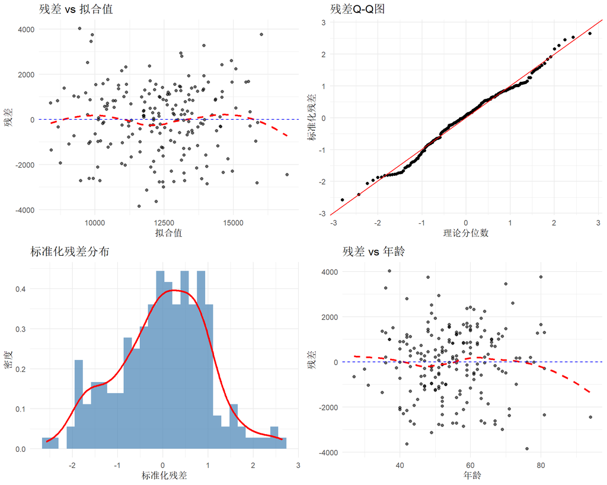

```r
# 提取残差和拟合值
residuals_std <- rstandard(model_ols)    # 标准化残差
residuals_stud <- rstudent(model_ols)    # 学生化残差
fitted_values <- fitted(model_ols)

# 创建诊断图数据框
diag_data <- data.frame(
  fitted = fitted_values,
  resid = residuals(model_ols),
  resid_std = residuals_std,
  resid_stud = residuals_stud
)

# 1. 残差vs拟合值图（检验异方差性）
p1 <- ggplot2::ggplot(diag_data, ggplot2::aes(x = fitted, y = resid)) +
  ggplot2::geom_point(alpha = 0.6) +
  ggplot2::geom_smooth(se = FALSE, color = "red", linetype = "dashed") +
  ggplot2::geom_hline(yintercept = 0, color = "blue", linetype = "dashed") +
  ggplot2::labs(title = "残差 vs 拟合值", x = "拟合值", y = "残差") +
  ggplot2::theme_minimal()

# 2. Q-Q图（检验正态性）
p2 <- ggplot2::ggplot(diag_data, ggplot2::aes(sample = resid_std)) +
  ggplot2::geom_qq() +
  ggplot2::geom_qq_line(color = "red") +
  ggplot2::labs(title = "残差Q-Q图", x = "理论分位数", y = "标准化残差") +
  ggplot2::theme_minimal()

# 3. 标准化残差直方图
p3 <- ggplot2::ggplot(diag_data, ggplot2::aes(x = resid_std)) +
  ggplot2::geom_histogram(ggplot2::aes(y = ggplot2::after_stat(density)),
                          bins = 30, fill = "steelblue", alpha = 0.7) +
  ggplot2::geom_density(color = "red", linewidth = 1) +
  ggplot2::labs(title = "标准化残差分布", x = "标准化残差", y = "密度") +
  ggplot2::theme_minimal()

# 4. 残差vs自变量图（以年龄为例）
diag_data$age <- medical_data$age
p4 <- ggplot2::ggplot(diag_data, ggplot2::aes(x = age, y = resid)) +
  ggplot2::geom_point(alpha = 0.6) +
  ggplot2::geom_smooth(se = FALSE, color = "red", linetype = "dashed") +
  ggplot2::geom_hline(yintercept = 0, color = "blue", linetype = "dashed") +
  ggplot2::labs(title = "残差 vs 年龄", x = "年龄", y = "残差") +
  ggplot2::theme_minimal()

# 组合图形
gridExtra::grid.arrange(p1, p2, p3, p4, ncol = 2)
```

```r
# 正态性检验：Shapiro-Wilk检验
shapiro_test <- shapiro.test(residuals(model_ols))
cat("\n========== 正态性检验 ==========\n")
```

```
##
## ========== 正态性检验 ==========
```

```r
cat(sprintf("Shapiro-Wilk检验: W = %.4f, p = %.4f\n",
            shapiro_test$statistic, shapiro_test$p.value))
```

```
## Shapiro-Wilk检验: W = 0.9878, p = 0.0830
```

```r
if (shapiro_test$p.value > 0.05) {
  cat("结论：p > 0.05，不能拒绝正态性假设，残差近似正态分布\n")
} else {
  cat("结论：p < 0.05，拒绝正态性假设，残差可能不服从正态分布\n")
}
```

```
## 结论：p > 0.05，不能拒绝正态性假设，残差近似正态分布
```

```r
# 异方差性检验：Breusch-Pagan检验
bp_test <- lmtest::bptest(model_ols)
cat("\n========== 异方差性检验 ==========\n")
```

```
##
## ========== 异方差性检验 ==========
```

```r
cat(sprintf("Breusch-Pagan检验: BP = %.4f, p = %.4f\n",
            bp_test$statistic, bp_test$p.value))
```

```
## Breusch-Pagan检验: BP = 2.6993, p = 0.4403
```

```r
if (bp_test$p.value > 0.05) {
  cat("结论：p > 0.05，不能拒绝同方差假设\n")
} else {
  cat("结论：p < 0.05，存在异方差性\n")
}
```

```
## 结论：p > 0.05，不能拒绝同方差假设
```

```r
# 异方差性检验：White检验（使用car包的ncvTest）
white_test <- car::ncvTest(model_ols)
cat(sprintf("White检验: Chi-square = %.4f, p = %.4f\n",
            white_test$ChiSquare, white_test$p))
```

```
## White检验: Chi-square = 0.1044, p = 0.7466
```

## 1.7 影响点与异常值诊断

### 意义与使用场景

**核心意义**：识别对模型估计有重大影响的观测点，这些点可能是数据录入错误、特殊群体或重要的发现。

**举例**：在医疗费用回归分析中，发现一位年轻患者费用异常高昂

**为什么这种数据适合用影响点诊断？**

首先，回归分析的结果（系数估计、标准误）对所有观测点的贡献是等权重的，个别极端值可能”拉动”回归线，改变整体结论。其次，医疗数据中存在多种异常情况：数据录入错误（费用多输一个零）、特殊病例（罕见并发症导致费用激增）、极端特征患者（超高龄或超低龄）。影响点诊断能够量化每个观测对模型的影响程度，避免被个别异常值误导。

**研究目的是什么？**

本研究有三个层次的目的：1. 识别异常值：找出Y方向（因变量）偏离模型预测较大的观测点；2. 识别高杠杆点：找出X方向（自变量）偏离数据主体的观测点；3. 识别强影响点：综合判断哪些观测对回归系数估计有重大影响，需要重点关注。

**可能得到什么样的结果？**

假设诊断结果显示：第47号观测的Cook距离=1.2（远超阈值4/n=0.04），学生化残差=3.5，杠杆值=0.15。

1. 异常值判断：学生化残差绝对值大于2，该患者的实际费用远高于模型预测值。
2. 杠杆值判断：杠杆值0.15超过阈值2(p+1)/n=0.08，该患者在自变量空间中位置特殊。
3. 影响程度：Cook距离1.2远超阈值，删除该观测后，年龄系数从200变为170，变化显著。
4. 原因分析：该患者为25岁但医疗费用高达15万元（因罕见手术），属于真实但特殊的病例。

**需要注意什么？**

影响点不一定是错误数据，也可能是真实但特殊的观测。处理策略应分三步：首先检查是否为数据录入错误；其次判断是否为与研究目的相关的特殊群体；最后决定是删除、单独分析还是保留并说明。切忌不加分析地删除所有影响点。

### 数学基础

**异常值与影响点的区别**：

| 概念 | 定义 | 识别方法 |
| --- | --- | --- |
| 异常值 | Y方向偏离模型预测的点 | 学生化残差 $\|t_i\| > 2$ |
| 高杠杆点 | X方向偏离数据主体的点 | 杠杆值 $h_{ii} > 2(p+1)/n$ |
| 强影响点 | 对模型估计有重大影响的点 | Cook距离 $D_i > 4/n$ 或 $> 1$ |

**杠杆值（Leverage）**：

$$h_{ii} =
\mathbf{x}_i'(\mathbf{X}'\mathbf{X})^{-1}\mathbf{x}_i$$

**参数说明**： - $h_{ii}$：帽子矩阵的第$i$个对角元素 - 取值范围：$1/n \leq h_{ii} \leq 1$ - $\sum_{i=1}^{n} h_{ii} = p+1$

**Cook距离**：

综合衡量第$i$个观测对回归系数估计的影响。

$$D_i = \frac{\sum_{j=1}^{n}(\hat{Y}_j -
\hat{Y}_{j(i)})^2}{(p+1)\hat{\sigma}^2} =
\frac{e_i^2}{(p+1)\hat{\sigma}^2} \cdot
\frac{h_{ii}}{(1-h_{ii})^2}$$

**参数说明**： - $\hat{Y}_{j(i)}$：删除第$i$个观测后第$j$个观测的拟合值 - $e_i$：第$i$个观测的残差

**DFFITS和DFBETAS**：

| 指标 | 公式 | 判断标准 |
| --- | --- | --- |
| DFFITS | $\frac{\hat{Y}_i - \hat{Y}_{i(i)}}{\hat{\sigma}_{(i)}\sqrt{h_{ii}}}$ | $\|DFFITS\| > 2\sqrt{(p+1)/n}$ |
| DFBETAS | $\frac{\hat{\beta}_j - \hat{\beta}_{j(i)}}{\hat{\sigma}_{(i)}\sqrt{c_{jj}}}$ | $\|DFBETAS\| > 2/\sqrt{n}$ |

### 代码实现

```r
# 计算各种诊断指标
influence_measures <- influence.measures(model_ols)
print(head(influence_measures$infmat, 10))
```

```
##           dfb.1_      dfb.age       dfb.bmi      dfb.los        dffit     cov.r
## 1  -7.398815e-02 -0.034764872  0.1365618895  0.002685856  0.155421745 1.0357346
## 2   1.147870e-03  0.001381330 -0.0065675600  0.007727469 -0.011811847 1.0447767
## 3  -2.983116e-03  0.012838685 -0.0023384401 -0.005578142  0.016262806 1.0437322
## 4   3.403865e-02 -0.012024291 -0.0546174341  0.001529761 -0.120046840 0.9812323
## 5   7.954218e-03  0.011067545 -0.0253263086  0.038100395  0.075436697 1.0152424
## 6  -1.822015e-05 -0.001694264  0.0005103219  0.001674205 -0.002628477 1.0628426
## 7  -2.114082e-02 -0.018793006  0.0313054998  0.015435010 -0.054180549 1.0261557
## 8  -1.149270e-01  0.131114438  0.0648830089 -0.060864300 -0.187682278 0.9989621
## 9   1.341265e-02  0.019691588 -0.0461786820  0.020418162 -0.062645654 1.0406981
## 10 -1.956328e-02  0.025063375  0.0052839783 -0.017725235 -0.066577376 1.0130052
##          cook.d         hat
## 1  6.045828e-03 0.030114585
## 2  3.505774e-05 0.023190158
## 3  6.645484e-05 0.022327031
## 4  3.580057e-03 0.006376240
## 5  1.425058e-03 0.008395402
## 6  1.736079e-06 0.039681241
## 7  7.366315e-04 0.010807768
## 8  8.764286e-03 0.017865461
## 9  9.852950e-04 0.022644150
## 10 1.109928e-03 0.006441036
```

```r
# 提取各项指标
leverage <- hatvalues(model_ols)           # 杠杆值
cooks_d <- cooks.distance(model_ols)       # Cook距离
dffits_val <- dffits(model_ols)            # DFFITS
dfbetas_val <- dfbetas(model_ols)          # DFBETAS
student_resid <- rstudent(model_ols)       # 学生化残差

# 创建诊断数据框
diag_df <- data.frame(
  obs = 1:nrow(medical_data),
  leverage = leverage,
  cooks_d = cooks_d,
  dffits = dffits_val,
  student_resid = student_resid
)

# 定义阈值
n <- nrow(medical_data)
p <- 3
leverage_threshold <- 2 * (p + 1) / n
cooks_threshold <- 4 / n
dffits_threshold <- 2 * sqrt((p + 1) / n)

# 识别异常点
outliers <- diag_df %>%
  dplyr::filter(
    abs(student_resid) > 2 |
    leverage > leverage_threshold |
    cooks_d > cooks_threshold
  )

cat("\n========== 诊断阈值 ==========\n")
```

```
##
## ========== 诊断阈值 ==========
```

```r
cat(sprintf("杠杆值阈值: %.4f\n", leverage_threshold))
```

```
## 杠杆值阈值: 0.0400
```

```r
cat(sprintf("Cook距离阈值: %.4f\n", cooks_threshold))
```

```
## Cook距离阈值: 0.0200
```

```r
cat(sprintf("DFFITS阈值: %.4f\n", dffits_threshold))
```

```
## DFFITS阈值: 0.2828
```

```r
cat(sprintf("学生化残差阈值: ±2\n"))
```

```
## 学生化残差阈值: ±2
```

```r
cat("\n========== 识别的异常/影响点 ==========\n")
```

```
##
## ========== 识别的异常/影响点 ==========
```

```r
print(outliers)
```

```
##     obs   leverage      cooks_d      dffits student_resid
## 16   16 0.05795669 0.1021429675 -0.64864728    -2.6151238
## 27   27 0.04121236 0.0005244277  0.04568947     0.2203757
## 30   30 0.03022504 0.0401014066  0.40483420     2.2931331
## 56   56 0.04078906 0.0046058067 -0.13553537    -0.6572610
## 65   65 0.04194878 0.0639143466 -0.51201842    -2.4469230
## 72   72 0.04008630 0.0020377733 -0.09009767    -0.4408914
## 95   95 0.04024865 0.0262480857 -0.32528173    -1.5884128
## 96   96 0.01766982 0.0269213049  0.33243233     2.4786540
## 97   97 0.05095437 0.0005341461 -0.04610982    -0.1989969
## 108 108 0.04475884 0.0096045464 -0.19591513    -0.9050761
## 135 135 0.05075307 0.0006292271 -0.05004666    -0.2164380
## 143 143 0.03423459 0.0412255967  0.40993853     2.1773185
## 146 146 0.02723047 0.0298559444 -0.34850853    -2.0830076
## 147 147 0.02864242 0.0516775839  0.46182692     2.6894531
## 149 149 0.06438679 0.1093807809  0.67073383     2.5568190
## 159 159 0.04325478 0.0343106092 -0.37241140    -1.7514755
## 164 164 0.08211808 0.0620214403 -0.50036200    -1.6728552
## 171 171 0.04027479 0.0366646550 -0.38543386    -1.8815106
## 174 174 0.03617286 0.0226828184 -0.30231716    -1.5605258
## 196 196 0.04436346 0.0082159831  0.18114851     0.8407530
## 198 198 0.04007857 0.0024281990 -0.09836017    -0.4813722
```

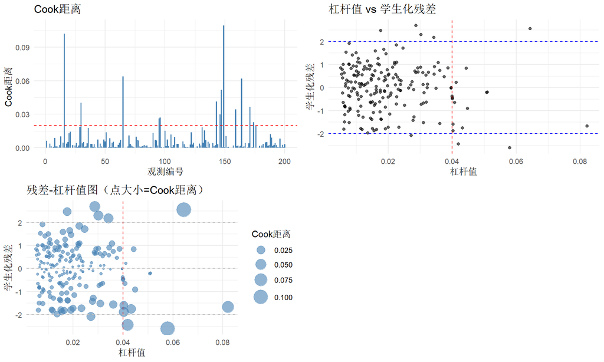

```r
# 可视化：Cook距离图
p1 <- ggplot2::ggplot(diag_df, ggplot2::aes(x = obs, y = cooks_d)) +
  ggplot2::geom_bar(stat = "identity", fill = "steelblue") +
  ggplot2::geom_hline(yintercept = cooks_threshold, color = "red", linetype = "dashed") +
  ggplot2::labs(title = "Cook距离", x = "观测编号", y = "Cook距离") +
  ggplot2::theme_minimal()

# 可视化：杠杆值 vs 学生化残差
p2 <- ggplot2::ggplot(diag_df, ggplot2::aes(x = leverage, y = student_resid)) +
  ggplot2::geom_point(alpha = 0.6) +
  ggplot2::geom_hline(yintercept = c(-2, 2), color = "blue", linetype = "dashed") +
  ggplot2::geom_vline(xintercept = leverage_threshold, color = "red", linetype = "dashed") +
  ggplot2::labs(title = "杠杆值 vs 学生化残差", x = "杠杆值", y = "学生化残差") +
  ggplot2::theme_minimal()

# 可视化：残差 vs 杠杆值（带Cook距离等高线）
p3 <- ggplot2::ggplot(diag_df, ggplot2::aes(x = leverage, y = student_resid, size = cooks_d)) +
  ggplot2::geom_point(alpha = 0.6, color = "steelblue") +
  ggplot2::scale_size_continuous(range = c(1, 8)) +
  ggplot2::geom_hline(yintercept = c(-2, 0, 2), color = "gray", linetype = "dashed") +
  ggplot2::geom_vline(xintercept = leverage_threshold, color = "red", linetype = "dashed") +
  ggplot2::labs(title = "残差-杠杆值图（点大小=Cook距离）",
                x = "杠杆值", y = "学生化残差", size = "Cook距离") +
  ggplot2::theme_minimal()

gridExtra::grid.arrange(p1, p2, p3, ncol = 2)
```

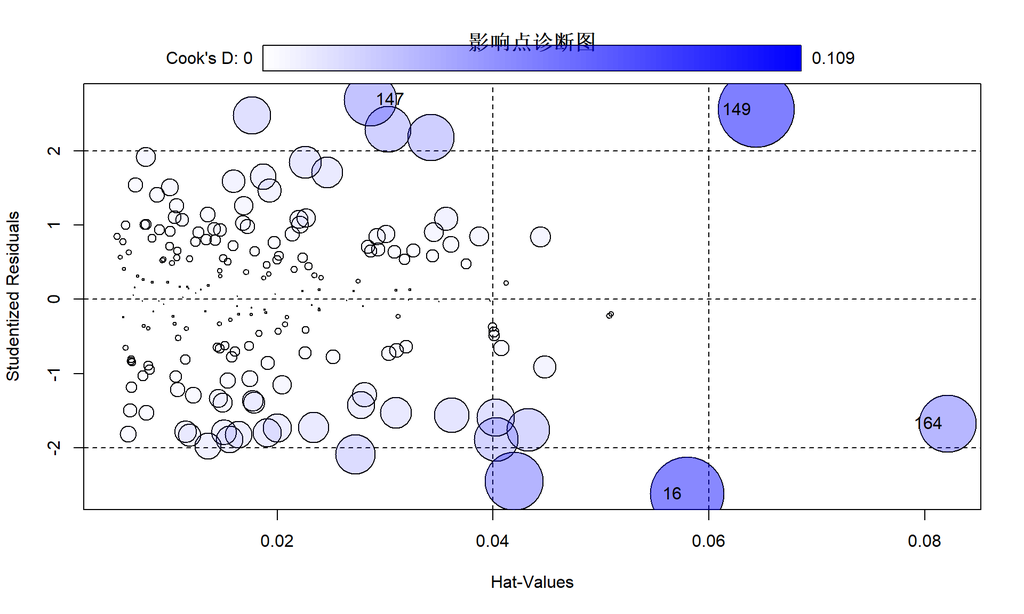

```
##       StudRes        Hat      CookD
## 16  -2.615124 0.05795669 0.10214297
## 147  2.689453 0.02864242 0.05167758
## 149  2.556819 0.06438679 0.10938078
## 164 -1.672855 0.08211808 0.06202144
```

```r
# 使用car包绘制综合诊断图
car::influencePlot(model_ols, main = "影响点诊断图")
```

## 1.8 多重共线性诊断

### 意义与使用场景

**核心意义**：多重共线性会导致回归系数估计不稳定、标准误增大，影响对变量重要性的判断。

**举例**：研究血压（收缩压）、舒张压、平均动脉压对心血管事件风险的影响

**为什么这种数据适合用多重共线性诊断？**

首先，三个血压指标之间存在数学关系：平均动脉压≈舒张压+1/3×脉压差，收缩压与舒张压高度相关（相关系数通常>0.7）。其次，当自变量高度相关时，回归模型难以区分各自的独立贡献，导致系数估计不稳定、标准误膨胀、符号可能反转。多重共线性诊断能够识别这些问题，指导变量选择或建模策略调整。

**研究目的是什么？**

本研究有三个层次的目的：1. 诊断共线性程度：计算VIF值，判断自变量之间是否存在严重的共线性问题；2. 评估影响：分析共线性对回归系数稳定性、标准误大小的影响；3. 指导解决方案：根据诊断结果决定是否删除变量、合并变量或采用其他建模方法。

**可能得到什么样的结果？**

假设VIF诊断结果显示：收缩压VIF=8.5，舒张压VIF=7.2，平均动脉压VIF=12.3。

1. 共线性判断：平均动脉压VIF>10，存在严重共线性；收缩压和舒张压VIF在5-10之间，存在中度共线性。
2. 原因分析：三个血压指标高度相关，平均动脉压可由收缩压和舒张压计算得出，信息高度重叠。
3. 对模型的影响：回归系数标准误增大，t值变小，可能导致本应显著的变量变得不显著。
4. 解决方案：删除平均动脉压，保留收缩压和舒张压；或使用主成分回归提取血压的综合指标。

**需要注意什么？**

多重共线性主要影响系数的解释和推断，对预测能力影响较小。如果研究目的是预测而非解释，可以容忍一定程度的共线性。解决共线性问题的方法包括：删除高度相关变量、主成分回归、岭回归、LASSO回归等，应根据研究目的选择。

### 数学基础

**多重共线性**：

自变量之间存在较强的线性关系，会导致回归系数估计不稳定、标准误增大。

**方差膨胀因子（VIF）**：

衡量每个自变量被其他自变量解释的程度。

$$VIF_j = \frac{1}{1-R_j^2}$$

**参数说明**： - $R_j^2$：以$X_j$为因变量，其他自变量为自变量进行回归的决定系数

**VIF判断标准**：

| VIF值 | 共线性程度 |
| --- | --- |
| VIF = 1 | 无共线性 |
| 1 < VIF < 5 | 轻度共线性 |
| 5 ≤ VIF < 10 | 中度共线性 |
| VIF ≥ 10 | 严重共线性 |

**条件数（Condition Number）**：

$$\kappa =
\sqrt{\frac{\lambda_{max}}{\lambda_{min}}}$$

**参数说明**： - $\lambda_{max}$、$\lambda_{min}$：设计矩阵$\mathbf{X}'\mathbf{X}$的最大、最小特征值 - $\kappa > 30$：存在严重共线性

**容忍度（Tolerance）**：
$$TOL_j = 1 - R_j^2 = \frac{1}{VIF_j}$$

### 代码实现

```r
# 计算VIF
vif_values <- car::vif(model_ols)
cat("========== 方差膨胀因子(VIF) ==========\n")
```

```
## ========== 方差膨胀因子(VIF) ==========
```

```r
print(vif_values)
```

```
##      age      bmi      los
## 1.001234 1.002648 1.002367
```

```r
# 创建VIF数据框
vif_df <- data.frame(
  Variable = names(vif_values),
  VIF = as.numeric(vif_values),
  Tolerance = 1/as.numeric(vif_values)
)

# 判断共线性程度
vif_df$Collinearity <- cut(vif_df$VIF,
                           breaks = c(0, 1, 5, 10, Inf),
                           labels = c("无", "轻度", "中度", "严重"))
print(vif_df)
```

```
##   Variable      VIF Tolerance Collinearity
## 1      age 1.001234 0.9987674         轻度
## 2      bmi 1.002648 0.9973592         轻度
## 3      los 1.002367 0.9976390         轻度
```

```r
# 计算条件数
X <- model.matrix(~ age + bmi + los, data = medical_data)
eigenvalues <- eigen(t(X) %*% X)$values
condition_number <- sqrt(max(eigenvalues) / min(eigenvalues))
cat(sprintf("\n条件数: %.2f\n", condition_number))
```

```
##
## 条件数: 533.63
```

```r
if (condition_number > 30) {
  cat("结论：条件数 > 30，存在严重多重共线性\n")
} else if (condition_number > 15) {
  cat("结论：条件数 > 15，存在中度多重共线性\n")
} else {
  cat("结论：多重共线性问题不严重\n")
}
```

```
## 结论：条件数 > 30，存在严重多重共线性
```

```r
# 模拟存在多重共线性的数据
cat("\n========== 模拟多重共线性示例 ==========\n")
```

```
##
## ========== 模拟多重共线性示例 ==========
```

```r
set.seed(456)
n_mc <- 100
x1 <- rnorm(n_mc, 50, 10)
x2 <- 2 * x1 + rnorm(n_mc, 0, 1)  # x2与x1高度相关
x3 <- rnorm(n_mc, 30, 5)
y_mc <- 100 + 5 * x1 + 3 * x2 + 2 * x3 + rnorm(n_mc, 0, 10)

data_mc <- data.frame(y = y_mc, x1 = x1, x2 = x2, x3 = x3)

# 查看相关系数矩阵
cor_matrix <- cor(data_mc[, c("x1", "x2", "x3")])
cat("\n相关系数矩阵：\n")
```

```
##
## 相关系数矩阵：
```

```r
print(round(cor_matrix, 3))
```

```
##       x1    x2    x3
## x1 1.000 0.999 0.126
## x2 0.999 1.000 0.127
## x3 0.126 0.127 1.000
```

```r
# 拟合模型并计算VIF
model_mc <- lm(y ~ x1 + x2 + x3, data = data_mc)
vif_mc <- car::vif(model_mc)
cat("\n存在共线性时的VIF：\n")
```

```
##
## 存在共线性时的VIF：
```

```r
print(vif_mc)
```

```
##         x1         x2         x3
## 425.683136 425.793113   1.016618
```

```r
# 解决方法：删除高度相关的变量
model_mc_fixed <- lm(y ~ x1 + x3, data = data_mc)
vif_mc_fixed <- car::vif(model_mc_fixed)
cat("\n删除x2后的VIF：\n")
```

```
##
## 删除x2后的VIF：
```

```r
print(vif_mc_fixed)
```

```
##       x1       x3
## 1.016031 1.016031
```

## 1.9 变量选择方法

### 意义与使用场景

**核心意义**：变量选择用于从众多候选变量中筛选出最重要的变量，构建简洁有效的预测模型。

**举例**：从20个临床指标中筛选出住院费用的关键预测因子

**为什么这种数据适合用变量选择方法？**

首先，临床数据中往往包含大量指标：人口学特征（年龄、性别）、生命体征（血压、心率）、实验室检查（血常规、生化）、既往病史等，其中部分变量可能与住院费用无关或相关性很弱。其次，纳入过多无关变量会导致模型过拟合、多重共线性、解释困难等问题。变量选择方法能够从候选变量中筛选出真正有预测价值的变量，在保证预测能力的前提下简化模型。

**研究目的是什么？**

本研究有三个层次的目的：1. 筛选关键变量：从20个候选变量中识别出对住院费用有显著影响的变量；2. 构建简洁模型：用最少的变量达到较好的预测效果，便于临床应用；3. 避免过拟合：通过AIC/BIC等准则惩罚复杂模型，提高模型的泛化能力。

**可能得到什么样的结果？**

假设逐步回归结果显示：最终模型包含5个变量（年龄、住院天数、手术类型、并发症数量、入院方式），AIC=2456。

1. 变量筛选结果：从20个候选变量中筛选出5个，模型变量数减少75%。
2. 预测能力：调整R²从0.72（全模型）下降到0.70（简化模型），损失很小。
3. 系数稳定性：VIF值均小于3，共线性问题得到改善。
4. 临床解释：年龄每增加1岁费用增加150元；住院天数每增加1天费用增加800元；手术类型和并发症数量是重要影响因素。

**需要注意什么？**

变量选择方法各有优劣：向前选择可能遗漏重要变量组合；向后消除要求样本量大于变量数；逐步选择最常用但可能陷入局部最优。AIC倾向于选择较大模型，BIC倾向于选择较小模型。建议结合专业知识，不要完全依赖统计方法，保留临床认为重要的变量。

### 数学基础

**变量选择的目标**：

在众多候选自变量中，选择最优的子集，使模型既简洁又有良好的预测能力。

**逐步回归方法**：

| 方法 | 过程 | 特点 |
| --- | --- | --- |
| 向前选择 | 从空模型开始，逐步加入变量 | 可能遗漏重要变量组合 |
| 向后消除 | 从全模型开始，逐步删除变量 | 要求样本量大于变量数 |
| 逐步选择 | 结合向前和向后，每步可进可退 | 最常用方法 |

**选择准则**：

1. **调整$R^2$**：最大化调整$R^2$
2. **AIC（Akaike Information Criterion）**：
   $$AIC = n\ln(RSS/n) + 2(p+1)$$
3. **BIC（Bayesian Information Criterion）**：
   $$BIC = n\ln(RSS/n) + \ln(n)(p+1)$$

**参数说明**： - AIC倾向于选择较大模型 - BIC惩罚更重，倾向于选择较小模型 - 选择AIC/BIC最小的模型

### 代码实现

```r
# 模拟更多变量的数据
set.seed(789)
n_var <- 200

# 生成候选自变量
x1 <- rnorm(n_var, 50, 10)
x2 <- rnorm(n_var, 25, 5)
x3 <- rnorm(n_var, 100, 20)
x4 <- rnorm(n_var, 30, 8)   # 与y无关的变量
x5 <- rnorm(n_var, 60, 15)  # 与y无关的变量
x6 <- rnorm(n_var, 45, 12)

# 生成因变量（只与x1, x2, x3, x6有关）
y_var <- 500 + 30 * x1 + 20 * x2 + 10 * x3 + 15 * x6 + rnorm(n_var, 0, 200)

data_var <- data.frame(y = y_var, x1 = x1, x2 = x2, x3 = x3, x4 = x4, x5 = x5, x6 = x6)

# 全模型
model_full <- lm(y ~ x1 + x2 + x3 + x4 + x5 + x6, data = data_var)
cat("========== 全模型摘要 ==========\n")
```

```
## ========== 全模型摘要 ==========
```

```r
print(summary(model_full)$coefficients)
```

```
##                Estimate  Std. Error    t value     Pr(>|t|)
## (Intercept) 308.8386911 163.5684900  1.8881307 6.050872e-02
## x1           30.3179244   1.4502559 20.9052245 1.799174e-51
## x2           21.7679069   2.8716316  7.5803273 1.408946e-12
## x3           11.3657796   0.7896631 14.3932016 2.186730e-32
## x4            0.1047781   1.8227801  0.0574826 9.542202e-01
## x5            0.1095493   0.9127274  0.1200241 9.045889e-01
## x6           14.0714379   1.2499950 11.2571952 6.333436e-23
```

```r
# 1. 向前选择
model_forward <- step(lm(y ~ 1, data = data_var),
                      scope = ~ x1 + x2 + x3 + x4 + x5 + x6,
                      direction = "forward",
                      trace = 0)
cat("\n========== 向前选择结果 ==========\n")
```

```
##
## ========== 向前选择结果 ==========
```

```r
print(summary(model_forward)$coefficients)
```

```
##              Estimate  Std. Error   t value     Pr(>|t|)
## (Intercept) 319.14958 138.7205506  2.300665 2.246826e-02
## x1           30.32355   1.4325139 21.168064 2.022762e-52
## x3           11.36879   0.7852374 14.478163 9.743120e-33
## x6           14.06194   1.2350110 11.386083 2.337435e-23
## x2           21.73477   2.8410956  7.650136 8.996289e-13
```

```r
# 2. 向后消除
model_backward <- step(model_full,
                       direction = "backward",
                       trace = 0)
cat("\n========== 向后消除结果 ==========\n")
```

```
##
## ========== 向后消除结果 ==========
```

```r
print(summary(model_backward)$coefficients)
```

```
##              Estimate  Std. Error   t value     Pr(>|t|)
## (Intercept) 319.14958 138.7205506  2.300665 2.246826e-02
## x1           30.32355   1.4325139 21.168064 2.022762e-52
## x2           21.73477   2.8410956  7.650136 8.996289e-13
## x3           11.36879   0.7852374 14.478163 9.743120e-33
## x6           14.06194   1.2350110 11.386083 2.337435e-23
```

```r
# 3. 逐步选择
model_stepwise <- step(model_full,
                       direction = "both",
                       trace = 0)
cat("\n========== 逐步选择结果 ==========\n")
```

```
##
## ========== 逐步选择结果 ==========
```

```r
print(summary(model_stepwise)$coefficients)
```

```
##              Estimate  Std. Error   t value     Pr(>|t|)
## (Intercept) 319.14958 138.7205506  2.300665 2.246826e-02
## x1           30.32355   1.4325139 21.168064 2.022762e-52
## x2           21.73477   2.8410956  7.650136 8.996289e-13
## x3           11.36879   0.7852374 14.478163 9.743120e-33
## x6           14.06194   1.2350110 11.386083 2.337435e-23
```

```r
# 4. 最佳子集选择
best_subset <- leaps::regsubsets(y ~ x1 + x2 + x3 + x4 + x5 + x6,
                                  data = data_var,
                                  nbest = 1,      # 每个变量数选1个最佳模型
                                  nvmax = 6)      # 最多6个变量
best_summary <- summary(best_subset)

cat("\n========== 最佳子集选择结果 ==========\n")
```

```
##
## ========== 最佳子集选择结果 ==========
```

```r
cat("各变量数的最优模型：\n")
```

```
## 各变量数的最优模型：
```

```r
for (i in 1:6) {
  vars <- names(which(best_summary$which[i, -1]))
  cat(sprintf("%d个变量: %s (调整R²=%.4f, BIC=%.2f)\n",
              i, paste(vars, collapse = "+"),
              best_summary$adjr2[i], best_summary$bic[i]))
}
```

```
## 1个变量: x1 (调整R²=0.4445, BIC=-107.98)
## 2个变量: x1+x3 (调整R²=0.6439, BIC=-192.65)
## 3个变量: x1+x3+x6 (调整R²=0.7587, BIC=-266.19)
## 4个变量: x1+x2+x3+x6 (调整R²=0.8135, BIC=-313.39)
## 5个变量: x1+x2+x3+x5+x6 (调整R²=0.8125, BIC=-308.10)
## 6个变量: x1+x2+x3+x4+x5+x6 (调整R²=0.8115, BIC=-302.81)
```

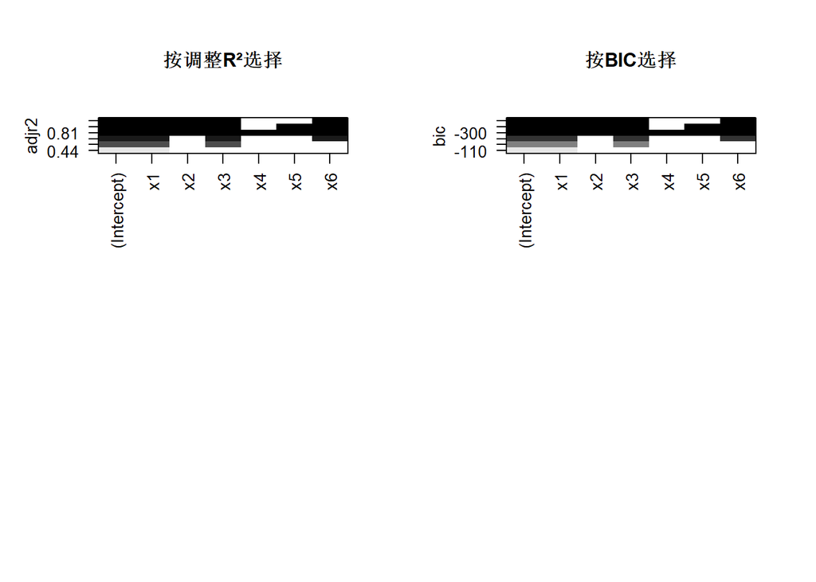

```r
# 可视化最佳子集选择结果
par(mfrow = c(2, 2))
plot(best_subset, scale = "adjr2", main = "按调整R²选择")
plot(best_subset, scale = "bic", main = "按BIC选择")
par(mfrow = c(1, 1))
```

```r
# 比较各模型的AIC和BIC
cat("\n========== 模型比较 ==========\n")
```

```
##
## ========== 模型比较 ==========
```

```r
cat(sprintf("全模型: AIC = %.2f, BIC = %.2f\n", AIC(model_full), BIC(model_full)))
```

```
## 全模型: AIC = 2704.37, BIC = 2730.75
```

```r
cat(sprintf("向前选择: AIC = %.2f, BIC = %.2f\n", AIC(model_forward), BIC(model_forward)))
```

```
## 向前选择: AIC = 2700.38, BIC = 2720.17
```

```r
cat(sprintf("向后消除: AIC = %.2f, BIC = %.2f\n", AIC(model_backward), BIC(model_backward)))
```

```
## 向后消除: AIC = 2700.38, BIC = 2720.17
```

```r
cat(sprintf("逐步选择: AIC = %.2f, BIC = %.2f\n", AIC(model_stepwise), BIC(model_stepwise)))
```

```
## 逐步选择: AIC = 2700.38, BIC = 2720.17
```

## 1.10 信息准则

### 意义与使用场景

**核心意义**：信息准则用于在模型拟合优度与复杂度之间取得平衡，帮助选择最优模型。

**举例**：比较三个住院费用预测模型，选择最优模型

**为什么这种数据适合用信息准则？**

首先，模型比较面临一个核心矛盾：增加变量总能提高拟合优度（R²单调递增），但可能导致过拟合，降低泛化能力。其次，医疗费用预测可能涉及多个候选模型：仅含人口学特征的简单模型、加入临床指标的复杂模型、加入交互项的更复杂模型。信息准则通过惩罚项平衡拟合优度与模型复杂度，帮助选择在预测和简洁之间取得平衡的最优模型。

**研究目的是什么？**

本研究有三个层次的目的：1. 模型比较：客观比较不同复杂度模型的优劣，避免主观判断；2. 防止过拟合：通过惩罚项抑制过度复杂的模型，提高模型泛化能力；3. 指导变量选择：结合逐步回归等方法，自动筛选最优变量组合。

**可能得到什么样的结果？**

假设三个候选模型的比较结果：模型A（3个变量）AIC=2520，模型B（5个变量）AIC=2485，模型C（7个变量）AIC=2490。

1. 最优模型选择：模型B的AIC值最小（2485），为最优模型。
2. 复杂度惩罚：模型C虽然变量更多，但AIC反而比模型B大5，说明增加的2个变量带来的拟合改善不足以抵消复杂度惩罚。
3. BIC比较：若使用BIC准则，模型A可能更优（BIC惩罚更重），适合以解释为主要目的的研究。
4. 模型差异判断：AIC差值>10表示模型差异显著，模型B明显优于模型A（差值35）。

**需要注意什么？**

AIC偏向预测，倾向于选择较大模型；BIC偏向解释，倾向于选择较小模型。信息准则仅适用于同一样本、同一因变量的模型比较，不能跨数据集比较。AIC/BIC差值小于2时，模型差异不显著，可结合专业知识和简洁原则选择。

### 数学基础

**信息准则**：

用于模型比较和选择，平衡模型拟合优度与复杂度。

**AIC（Akaike Information Criterion）**：
$$AIC = -2\ln(L) + 2k$$

对于线性回归：
$$AIC = n\ln(RSS/n) +
2(p+1) + n + n\ln(2\pi)$$

**BIC（Bayesian Information Criterion）**：
$$BIC = -2\ln(L) + k\ln(n)$$

对于线性回归：
$$BIC = n\ln(RSS/n) +
(p+1)\ln(n) + n + n\ln(2\pi)$$

**参数说明**： - $L$：模型的极大似然值 - $k$：参数个数（包括截距） - $n$：样本量 - $p$：自变量个数

**HQIC（Hannan-Quinn Information Criterion）**：
$$HQIC = -2\ln(L) + 2k\ln(\ln(n))$$

**准则比较**：

| 准则 | 惩罚项 | 倾向 | 适用场景 |
| --- | --- | --- | --- |
| AIC | $2k$ | 较大模型 | 预测为目的 |
| BIC | $k\ln(n)$ | 较小模型 | 解释为目的、大样本 |
| HQIC | $2k\ln(\ln(n))$ | 介于AIC和BIC之间 | 中等样本 |

**选择原则**：选择信息准则值最小的模型。

### 代码实现

```r
# 使用之前的医疗费用数据
# 比较不同模型的AIC、BIC

# 候选模型
model_1 <- lm(medical_cost ~ age, data = medical_data)
model_2 <- lm(medical_cost ~ age + bmi, data = medical_data)
model_3 <- lm(medical_cost ~ age + bmi + los, data = medical_data)
model_4 <- lm(medical_cost ~ age * bmi + los, data = medical_data)  # 含交互项

# 计算各模型的信息准则
compare_df <- data.frame(
  Model = c("age", "age+bmi", "age+bmi+los", "age*bmi+los"),
  AIC = c(AIC(model_1), AIC(model_2), AIC(model_3), AIC(model_4)),
  BIC = c(BIC(model_1), BIC(model_2), BIC(model_3), BIC(model_4)),
  Adj_R2 = c(summary(model_1)$adj.r.squared,
             summary(model_2)$adj.r.squared,
             summary(model_3)$adj.r.squared,
             summary(model_4)$adj.r.squared)
)

cat("========== 模型比较 ==========\n")
```

```
## ========== 模型比较 ==========
```

```r
print(compare_df)
```

```
##         Model      AIC      BIC    Adj_R2
## 1         age 3665.081 3674.976 0.0318859
## 2     age+bmi 3636.672 3649.865 0.1642201
## 3 age+bmi+los 3509.785 3526.276 0.5590117
## 4 age*bmi+los 3510.523 3530.313 0.5595367
```

```r
# 找出最优模型
best_aic_model <- compare_df$Model[which.min(compare_df$AIC)]
best_bic_model <- compare_df$Model[which.min(compare_df$BIC)]
best_adjr2_model <- compare_df$Model[which.max(compare_df$Adj_R2)]

cat(sprintf("\n按AIC最优: %s\n", best_aic_model))
```

```
##
## 按AIC最优: age+bmi+los
```

```r
cat(sprintf("按BIC最优: %s\n", best_bic_model))
```

```
## 按BIC最优: age+bmi+los
```

```r
cat(sprintf("按调整R²最优: %s\n", best_adjr2_model))
```

```
## 按调整R²最优: age*bmi+los
```

```r
# 使用AICc（小样本校正AIC）
# AICc = AIC + 2k(k+1)/(n-k-1)
n <- nrow(medical_data)

calc_aicc <- function(model) {
  k <- length(coef(model))
  aic <- AIC(model)
  aicc <- aic + 2 * k * (k + 1) / (n - k - 1)
  return(aicc)
}

compare_df$AICc <- c(calc_aicc(model_1), calc_aicc(model_2),
                     calc_aicc(model_3), calc_aicc(model_4))

cat("\n========== 含AICc的模型比较 ==========\n")
```

```
##
## ========== 含AICc的模型比较 ==========
```

```r
print(compare_df)
```

```
##         Model      AIC      BIC    Adj_R2     AICc
## 1         age 3665.081 3674.976 0.0318859 3665.142
## 2     age+bmi 3636.672 3649.865 0.1642201 3636.794
## 3 age+bmi+los 3509.785 3526.276 0.5590117 3509.990
## 4 age*bmi+los 3510.523 3530.313 0.5595367 3510.833
```

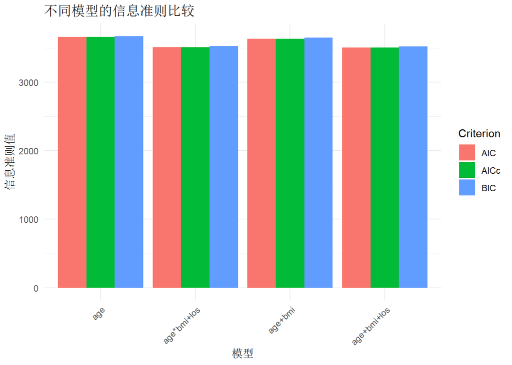

```r
# 可视化
compare_long <- compare_df %>%
  tidyr::pivot_longer(cols = c(AIC, BIC, AICc),
                      names_to = "Criterion", values_to = "Value")

ggplot2::ggplot(compare_long, ggplot2::aes(x = Model, y = Value, fill = Criterion)) +
  ggplot2::geom_bar(stat = "identity", position = "dodge") +
  ggplot2::labs(title = "不同模型的信息准则比较", x = "模型", y = "信息准则值") +
  ggplot2::theme_minimal() +
  ggplot2::theme(axis.text.x = ggplot2::element_text(angle = 45, hjust = 1))
```

## 1.11 稳健标准误

### 意义与使用场景

**核心意义**：当经典假设（如同方差性）不满足时，稳健标准误可以提供有效的统计推断。

**适用场景**： - **概括**：当数据存在异方差或聚类结构时，使用稳健标准误校正标准误估计 - **医学举例**：多中心临床试验中，同一中心的患者可能相关，需用聚类稳健标准误 - **其他领域**：面板数据分析；教育研究中同一学校学生的数据

**核心优势**：即使模型假设不完全满足，仍能得到可靠的置信区间和假设检验结果

### 数学基础

**稳健标准误（Robust Standard Errors）**：

当经典假设（如同方差性）不满足时，使用稳健标准误可以获得有效的统计推断。

**异方差稳健标准误（HC标准误）**：

**White/Huber-White标准误**：
$$Var(\hat{\boldsymbol{\beta}})_{robust} =
(\mathbf{X}'\mathbf{X})^{-1}\mathbf{X}'\hat{\Omega}\mathbf{X}(\mathbf{X}'\mathbf{X})^{-1}$$

其中$\hat{\Omega}$是对角矩阵，对角元素为$\hat{\omega}_i = e_i^2$。

**HC类型**：

| 类型 | 公式 | 特点 |
| --- | --- | --- |
| HC0 | $\hat{\omega}_i = e_i^2$ | 原始White估计 |
| HC1 | $\hat{\omega}_i = \frac{n}{n-p-1}e_i^2$ | 小样本校正 |
| HC2 | $\hat{\omega}_i = \frac{e_i^2}{1-h_{ii}}$ | 考虑杠杆值 |
| HC3 | $\hat{\omega}_i = \frac{e_i^2}{(1-h_{ii})^2}$ | 更保守，推荐使用 |

**聚类稳健标准误**：

当观测值在组内相关时使用。

$$Var(\hat{\boldsymbol{\beta}})_{cluster}
=
(\mathbf{X}'\mathbf{X})^{-1}\left(\sum_{g=1}^{G}\mathbf{X}_g'\mathbf{e}_g\mathbf{e}_g'\mathbf{X}_g\right)(\mathbf{X}'\mathbf{X})^{-1}$$

**参数说明**： - $G$：聚类数量 - $\mathbf{X}_g$、$\mathbf{e}_g$：第$g$组的设计矩阵和残差向量

### 代码实现

```r
# 模拟存在异方差的数据
set.seed(111)
n_het <- 200
x_het <- rnorm(n_het, 50, 15)
# 误差方差随x增大而增大
epsilon_het <- rnorm(n_het, 0, x_het / 10)
y_het <- 100 + 2 * x_het + epsilon_het

data_het <- data.frame(x = x_het, y = y_het)

# OLS回归
model_het <- lm(y ~ x, data = data_het)

# 普通标准误
summary_normal <- summary(model_het)

# 异方差稳健标准误（使用sandwich包）
# HC0
vcov_hc0 <- sandwich::vcovHC(model_het, type = "HC0")
# HC1（Stata默认）
vcov_hc1 <- sandwich::vcovHC(model_het, type = "HC1")
# HC2
vcov_hc2 <- sandwich::vcovHC(model_het, type = "HC2")
# HC3（推荐）
vcov_hc3 <- sandwich::vcovHC(model_het, type = "HC3")

# 使用lmtest包输出稳健标准误结果
cat("========== 普通标准误 ==========\n")
```

```
## ========== 普通标准误 ==========
```

```r
print(lmtest::coeftest(model_het))
```

```
##
## t test of coefficients:
##
##              Estimate Std. Error t value  Pr(>|t|)
## (Intercept) 100.95612    1.12573  89.681 < 2.2e-16 ***
## x             1.98626    0.02158  92.041 < 2.2e-16 ***
## ---
## Signif. codes:  0 '***' 0.001 '**' 0.01 '*' 0.05 '.' 0.1 ' ' 1
```

```r
cat("\n========== HC0稳健标准误 ==========\n")
```

```
##
## ========== HC0稳健标准误 ==========
```

```r
print(lmtest::coeftest(model_het, vcov = vcov_hc0))
```

```
##
## t test of coefficients:
##
##               Estimate Std. Error t value  Pr(>|t|)
## (Intercept) 100.956117   0.887777  113.72 < 2.2e-16 ***
## x             1.986265   0.019948   99.57 < 2.2e-16 ***
## ---
## Signif. codes:  0 '***' 0.001 '**' 0.01 '*' 0.05 '.' 0.1 ' ' 1
```

```r
cat("\n========== HC1稳健标准误 ==========\n")
```

```
##
## ========== HC1稳健标准误 ==========
```

```r
print(lmtest::coeftest(model_het, vcov = vcov_hc1))
```

```
##
## t test of coefficients:
##
##               Estimate Std. Error t value  Pr(>|t|)
## (Intercept) 100.956117   0.892249 113.148 < 2.2e-16 ***
## x             1.986265   0.020049  99.071 < 2.2e-16 ***
## ---
## Signif. codes:  0 '***' 0.001 '**' 0.01 '*' 0.05 '.' 0.1 ' ' 1
```

```r
cat("\n========== HC3稳健标准误（推荐） ==========\n")
```

```
##
## ========== HC3稳健标准误（推荐） ==========
```

```r
print(lmtest::coeftest(model_het, vcov = vcov_hc3))
```

```
##
## t test of coefficients:
##
##               Estimate Std. Error t value  Pr(>|t|)
## (Intercept) 100.956117   0.905385  111.51 < 2.2e-16 ***
## x             1.986265   0.020349   97.61 < 2.2e-16 ***
## ---
## Signif. codes:  0 '***' 0.001 '**' 0.01 '*' 0.05 '.' 0.1 ' ' 1
```

```r
# 比较标准误
se_compare <- data.frame(
  Type = c("普通", "HC0", "HC1", "HC2", "HC3"),
  SE_intercept = c(
    sqrt(diag(vcov(model_het)))[1],
    sqrt(diag(vcov_hc0))[1],
    sqrt(diag(vcov_hc1))[1],
    sqrt(diag(vcov_hc2))[1],
    sqrt(diag(vcov_hc3))[1]
  ),
  SE_x = c(
    sqrt(diag(vcov(model_het)))[2],
    sqrt(diag(vcov_hc0))[2],
    sqrt(diag(vcov_hc1))[2],
    sqrt(diag(vcov_hc2))[2],
    sqrt(diag(vcov_hc3))[2]
  )
)

cat("\n========== 标准误比较 ==========\n")
```

```
##
## ========== 标准误比较 ==========
```

```r
print(se_compare)
```

```
##   Type SE_intercept       SE_x
## 1 普通    1.1257267 0.02158012
## 2  HC0    0.8877767 0.01994843
## 3  HC1    0.8922491 0.02004892
## 4  HC2    0.8965045 0.02014697
## 5  HC3    0.9053845 0.02034890
```

```r
# 聚类稳健标准误示例
# 模拟聚类数据
set.seed(222)
n_clusters <- 20
n_per_cluster <- 10
n_cluster <- n_clusters * n_per_cluster

cluster_id <- rep(1:n_clusters, each = n_per_cluster)
x_cluster <- rnorm(n_cluster, 50, 10)
# 组内相关的误差
cluster_effect <- rnorm(n_clusters, 0, 5)[cluster_id]
epsilon_cluster <- rnorm(n_cluster, 0, 3) + cluster_effect
y_cluster <- 100 + 2 * x_cluster + epsilon_cluster

data_cluster <- data.frame(
  cluster = factor(cluster_id),
  x = x_cluster,
  y = y_cluster
)

model_cluster <- lm(y ~ x, data = data_cluster)

# 聚类稳健标准误
vcov_cl <- sandwich::vcovCL(model_cluster, cluster = data_cluster$cluster)

cat("\n========== 聚类稳健标准误 ==========\n")
```

```
##
## ========== 聚类稳健标准误 ==========
```

```r
cat("普通标准误：\n")
```

```
## 普通标准误：
```

```r
print(lmtest::coeftest(model_cluster))
```

```
##
## t test of coefficients:
##
##              Estimate Std. Error t value  Pr(>|t|)
## (Intercept) 98.437958   2.182343  45.106 < 2.2e-16 ***
## x            2.048868   0.042776  47.898 < 2.2e-16 ***
## ---
## Signif. codes:  0 '***' 0.001 '**' 0.01 '*' 0.05 '.' 0.1 ' ' 1
```

```r
cat("\n聚类稳健标准误：\n")
```

```
##
## 聚类稳健标准误：
```

```r
print(lmtest::coeftest(model_cluster, vcov = vcov_cl))
```

```
##
## t test of coefficients:
##
##              Estimate Std. Error t value  Pr(>|t|)
## (Intercept) 98.437958   3.719596  26.465 < 2.2e-16 ***
## x            2.048868   0.059659  34.343 < 2.2e-16 ***
## ---
## Signif. codes:  0 '***' 0.001 '**' 0.01 '*' 0.05 '.' 0.1 ' ' 1
```